# ponderada_S1

Julia Togni

2024-08-06

## Bibliotecas necessárias

```r
library(dplyr)
```

```r
library(tibble)
library(ggplot2)
library(corrplot)
library(FactoMineR)
library(factoextra)
```

## Carregamento e Preparação dos Dados

```r
ano_2018 <- read.csv("./datasets/2018.csv")
store_final <- read.csv("./datasets/store_final.csv")
target_store_final <- read.csv("./datasets/target_store_final.csv")
sku_status_dataset <- read.csv2("./datasets/sku_status_dataset.csv")
targets_salesperson_final <- read.csv("./datasets/targets_salesperson_final.csv")
sku_price <- read.csv("./datasets/sku_price.csv")
sku_dataset <- read.csv2("./datasets/sku_dataset.csv")
sku_cost <- read.csv("./datasets/sku_cost.csv")
employee_final <- read.csv("./datasets/employee_final.csv")
```

##### Convertendo dataframes para tibbles

```r
ano_2018 <- as_tibble(ano_2018)
store_final <- as_tibble(store_final)
target_store_final <- as_tibble(target_store_final)
sku_status_dataset <- as_tibble(sku_status_dataset)
targets_salesperson_final <- as_tibble(targets_salesperson_final)
sku_price <- as_tibble(sku_price)
sku_dataset <- as_tibble(sku_dataset)
sku_cost <- as_tibble(sku_cost)
employee_final <- as_tibble(employee_final)
```

##### Visualizando as primeiras linhas de cada dataset

```r
head(ano_2018)
```

```
## # A tibble: 6 × 7
##   data       cod_vendedor cod_loja       cod_transacao quantidade cod_prod preco
##   <chr>             <int> <chr>          <chr>              <int>    <dbl> <dbl>
## 1 2018-04-21          421 MG_70          0000005004             2  8.57e11  76.4
## 2 2018-04-23          860 SC_18          0002e30ac4             4  7.15e11 146.
## 3 2018-04-26          711 SP Capital Su… 000708876e             4  1.22e10  94.6
## 4 2018-04-26          711 SP Capital Su… 000708876e             1  5.69e11  36.4
## 5 2018-04-26          711 SP Capital Su… 000708876e             6  9.72e11 175.
## 6 2018-04-20          373 SP Capital Ce… 000708b167             2  9.32e10  58.2
```

```r
head(store_final)
```

```
## # A tibble: 6 × 4
##   nome_loja         regiao         diretoria data_inauguracao
##   <chr>             <chr>          <chr>     <chr>
## 1 SP Capital Sul_59 SP Capital Sul Grande SP 09/08/2020
## 2 SP Capital Sul_30 SP Capital Sul Grande SP 05/03/2000
## 3 SP Capital Sul_17 SP Capital Sul Grande SP 28/02/2019
## 4 SP Capital Sul_9  SP Capital Sul Grande SP 16/05/2001
## 5 SP Capital Sul_97 SP Capital Sul Grande SP 12/07/2017
## 6 SP Capital Sul_90 SP Capital Sul Grande SP 15/04/2000
```

```r
head(target_store_final)
```

```
## # A tibble: 6 × 3
##   month   store_id sales_target
##   <chr>   <chr>           <int>
## 1 01/2000 MG_21          116070
## 2 01/2000 MG_23          102199
## 3 01/2000 MG_24           98628
## 4 01/2000 MG_26          113215
## 5 01/2000 MG_29          113450
## 6 01/2000 MG_34          116066
```

```r
head(sku_status_dataset)
```

```
## # A tibble: 6 × 3
##       cod_prod data_inicio data_fim
##          <dbl> <chr>       <chr>
## 1 603078352615 2007-08-02  "2023-09-16"
## 2 131384024501 2006-08-22  "2020-05-12"
## 3  85873708529 2000-03-05  ""
## 4 579926605113 2011-05-05  "2018-06-23"
## 5 397769055946 2006-07-15  ""
## 6 981647487600 2021-04-02  ""
```

```r
head(targets_salesperson_final)
```

```
## # A tibble: 6 × 3
##   id_employee sales_target month
##         <int>        <int> <chr>
## 1         643        25088 01/2000
## 2         643        39703 02/2000
## 3         643        23478 03/2000
## 4         643        22417 04/2000
## 5         643        25622 05/2000
## 6         643        32298 06/2000
```

```r
head(sku_price)
```

```
## # A tibble: 6 × 4
##       cod_prod data_inicio data_fim   preco
##          <dbl> <chr>       <chr>      <dbl>
## 1 603078352615 2007-08-02  2009-08-07  26.0
## 2 603078352615 2009-08-08  2011-08-14  27.0
## 3 603078352615 2011-08-15  2013-08-20  28.0
## 4 603078352615 2013-08-21  2015-08-27  28.0
## 5 603078352615 2015-08-28  2017-09-02  29.0
## 6 603078352615 2017-09-03  2019-09-09  30.0
```

```r
head(sku_dataset)
```

```
## # A tibble: 6 × 9
##       cod_prod nome_abrev  nome_completo descricao categoria sub_categoria marca
##          <dbl> <chr>       <chr>         <chr>     <chr>     <chr>         <chr>
## 1 603078352615 Acne Solut… Acne Solutio… Sabonete… Corpo     Sabonete líq… Clin…
## 2 131384024501 Pep Start … Pep Start Da… Protetor… Corpo     Protetor sol… Clin…
## 3  85873708529 Deep Comfo… Deep Comfort… Sabonete… Corpo     Sabonete líq… Clin…
## 4 579926605113 Lipikar Wa… Lipikar Wash… Sabonete… Corpo     Sabonete líq… La R…
## 5 397769055946 Anthelios … Anthelios AO… Protetor… Corpo     Protetor sol… La R…
## 6 981647487600 Basil Whit… Basil & Whit… Sabonete… Corpo     Sabonete líq… Nivea
## # ℹ 2 more variables: conteudo_valor <chr>, conteudo_medida <chr>
```

```r
head(sku_cost)
```

```
## # A tibble: 6 × 4
##       cod_prod data_inicio data_fim   custo
##          <dbl> <chr>       <chr>      <dbl>
## 1 603078352615 2007-08-02  2011-08-13  26.2
## 2 603078352615 2011-08-14  2015-08-25  27.1
## 3 603078352615 2015-08-26  2019-09-06  27.5
## 4 603078352615 2019-09-07  2023-09-16  27.6
## 5 131384024501 2006-08-22  2009-05-20  70.8
## 6 131384024501 2009-05-21  2012-02-17  71.6
```

```r
head(employee_final)
```

```
## # A tibble: 6 × 9
##   id_employee name     surname cpf   status role  initial_date end_date store_id
##         <int> <chr>    <chr>   <chr> <chr>  <chr> <chr>        <chr>    <chr>
## 1         643 Antonel… da Cruz 938.… ativo  gere… 14/12/2007   ""       MG_21
## 2         924 Carlos … Alves   501.… ativo  vend… 29/09/2014   ""       MG_21
## 3         567 Ana Sop… Ramos   980.… ativo  vend… 03/04/2006   ""       MG_21
## 4         660 Marcela  Brito   859.… ativo  vend… 14/03/2003   ""       MG_21
## 5         297 Leonardo Porto   652.… ativo  vend… 27/06/2021   ""       MG_23
## 6         523 Heitor   Sales   472.… ativo  vend… 11/09/2021   ""       MG_23
```

##### Visualizando a estrutura de cada dataset

```r
str(ano_2018)
```

```
## tibble [3,578,618 × 7] (S3: tbl_df/tbl/data.frame)
##  $ data         : chr [1:3578618] "2018-04-21" "2018-04-23" "2018-04-26" "2018-04-26" ...
##  $ cod_vendedor : int [1:3578618] 421 860 711 711 711 373 373 615 410 774 ...
##  $ cod_loja     : chr [1:3578618] "MG_70" "SC_18" "SP Capital Sul_30" "SP Capital Sul_30" ...
##  $ cod_transacao: chr [1:3578618] "0000005004" "0002e30ac4" "000708876e" "000708876e" ...
##  $ quantidade   : int [1:3578618] 2 4 4 1 6 2 4 2 4 3 ...
##  $ cod_prod     : num [1:3578618] 8.57e+11 7.15e+11 1.22e+10 5.69e+11 9.72e+11 ...
##  $ preco        : num [1:3578618] 76.4 145.5 94.6 36.4 174.6 ...
```

```r
str(store_final)
```

```
## tibble [205 × 4] (S3: tbl_df/tbl/data.frame)
##  $ nome_loja       : chr [1:205] "SP Capital Sul_59" "SP Capital Sul_30" "SP Capital Sul_17" "SP Capital Sul_9" ...
##  $ regiao          : chr [1:205] "SP Capital Sul" "SP Capital Sul" "SP Capital Sul" "SP Capital Sul" ...
##  $ diretoria       : chr [1:205] "Grande SP" "Grande SP" "Grande SP" "Grande SP" ...
##  $ data_inauguracao: chr [1:205] "09/08/2020" "05/03/2000" "28/02/2019" "16/05/2001" ...
```

```r
str(target_store_final)
```

```
## tibble [61,500 × 3] (S3: tbl_df/tbl/data.frame)
##  $ month       : chr [1:61500] "01/2000" "01/2000" "01/2000" "01/2000" ...
##  $ store_id    : chr [1:61500] "MG_21" "MG_23" "MG_24" "MG_26" ...
##  $ sales_target: int [1:61500] 116070 102199 98628 113215 113450 116066 133941 116652 110423 134822 ...
```

```r
str(sku_status_dataset)
```

```
## tibble [563 × 3] (S3: tbl_df/tbl/data.frame)
##  $ cod_prod   : num [1:563] 6.03e+11 1.31e+11 8.59e+10 5.80e+11 3.98e+11 ...
##  $ data_inicio: chr [1:563] "2007-08-02" "2006-08-22" "2000-03-05" "2011-05-05" ...
##  $ data_fim   : chr [1:563] "2023-09-16" "2020-05-12" "" "2018-06-23" ...
```

```r
str(targets_salesperson_final)
```

```
## tibble [246,000 × 3] (S3: tbl_df/tbl/data.frame)
##  $ id_employee : int [1:246000] 643 643 643 643 643 643 643 643 643 643 ...
##  $ sales_target: int [1:246000] 25088 39703 23478 22417 25622 32298 37406 26462 21400 35700 ...
##  $ month       : chr [1:246000] "01/2000" "02/2000" "03/2000" "04/2000" ...
```

```r
str(sku_price)
```

```
## tibble [5,323 × 4] (S3: tbl_df/tbl/data.frame)
##  $ cod_prod   : num [1:5323] 6.03e+11 6.03e+11 6.03e+11 6.03e+11 6.03e+11 ...
##  $ data_inicio: chr [1:5323] "2007-08-02" "2009-08-08" "2011-08-15" "2013-08-21" ...
##  $ data_fim   : chr [1:5323] "2009-08-07" "2011-08-14" "2013-08-20" "2015-08-27" ...
##  $ preco      : num [1:5323] 26 27 28 28 29 ...
```

```r
str(sku_dataset)
```

```
## tibble [563 × 9] (S3: tbl_df/tbl/data.frame)
##  $ cod_prod       : num [1:563] 6.03e+11 1.31e+11 8.59e+10 5.80e+11 3.98e+11 ...
##  $ nome_abrev     : chr [1:563] "Acne Solutions Cleansing Bar" "Pep Start Daily UV" "Deep Comfort Body Wash" "Lipikar Wash Gentle Foaming" ...
##  $ nome_completo  : chr [1:563] "Acne Solutions Cleansing Bar for Face & Body" "Pep Start Daily UV Protector Broad Spectrum SPF 50" "Deep Comfort Body Wash" "Lipikar Wash AP+ Gentle Foaming Moisturizing Wash" ...
##  $ descricao      : chr [1:563] "Sabonete líquido Clinique Acne Solutions Cleansing Bar for Face & Body  para Corpo" "Protetor solar Clinique Pep Start Daily UV Protector Broad Spectrum SPF 50  para Corpo" "Sabonete líquido Clinique Deep Comfort Body Wash  para Corpo" "Sabonete líquido La Roche-P…
##  $ categoria      : chr [1:563] "Corpo" "Corpo" "Corpo" "Corpo" ...
##  $ sub_categoria  : chr [1:563] "Sabonete líquido" "Protetor solar" "Sabonete líquido" "Sabonete líquido" ...
##  $ marca          : chr [1:563] "Clinique" "Clinique" "Clinique" "La Roche-Posay" ...
##  $ conteudo_valor : chr [1:563] "156.0" "30.0" "204.0" "405.0" ...
##  $ conteudo_medida: chr [1:563] "ml" "ml" "ml" "ml" ...
```

```r
str(sku_cost)
```

```
## tibble [2,235 × 4] (S3: tbl_df/tbl/data.frame)
##  $ cod_prod   : num [1:2235] 6.03e+11 6.03e+11 6.03e+11 6.03e+11 1.31e+11 ...
##  $ data_inicio: chr [1:2235] "2007-08-02" "2011-08-14" "2015-08-26" "2019-09-07" ...
##  $ data_fim   : chr [1:2235] "2011-08-13" "2015-08-25" "2019-09-06" "2023-09-16" ...
##  $ custo      : num [1:2235] 26.2 27.1 27.5 27.6 70.8 ...
```

```r
str(employee_final)
```

```
## tibble [920 × 9] (S3: tbl_df/tbl/data.frame)
##  $ id_employee : int [1:920] 643 924 567 660 297 523 264 834 693 417 ...
##  $ name        : chr [1:920] "Antonella" "Carlos Eduardo" "Ana Sophia" "Marcela" ...
##  $ surname     : chr [1:920] "da Cruz" "Alves" "Ramos" "Brito" ...
##  $ cpf         : chr [1:920] "938.507.461-00" "501.639.827-59" "980.413.526-42" "859.163.742-91" ...
##  $ status      : chr [1:920] "ativo" "ativo" "ativo" "ativo" ...
##  $ role        : chr [1:920] "gerente" "vendedor" "vendedor" "vendedor" ...
##  $ initial_date: chr [1:920] "14/12/2007" "29/09/2014" "03/04/2006" "14/03/2003" ...
##  $ end_date    : chr [1:920] "" "" "" "" ...
##  $ store_id    : chr [1:920] "MG_21" "MG_21" "MG_21" "MG_21" ...
```

## Resumo Estatístico e Descrição dos Dados

```r
summary(ano_2018)
```

```
##      data            cod_vendedor     cod_loja         cod_transacao
##  Length:3578618     Min.   :  2.0   Length:3578618     Length:3578618
##  Class :character   1st Qu.:254.0   Class :character   Class :character
##  Mode  :character   Median :492.0   Mode  :character   Mode  :character
##                     Mean   :496.8
##                     3rd Qu.:753.0
##                     Max.   :997.0
##    quantidade       cod_prod             preco
##  Min.   :1.000   Min.   :8.312e+09   Min.   :   9.089
##  1st Qu.:2.000   1st Qu.:2.488e+11   1st Qu.:  95.923
##  Median :4.000   Median :4.677e+11   Median : 191.017
##  Mean   :3.795   Mean   :4.999e+11   Mean   : 324.356
##  3rd Qu.:5.000   3rd Qu.:7.733e+11   3rd Qu.: 364.877
##  Max.   :8.000   Max.   :9.970e+11   Max.   :4006.774
```

```r
summary(store_final)
```

```
##   nome_loja            regiao           diretoria         data_inauguracao
##  Length:205         Length:205         Length:205         Length:205
##  Class :character   Class :character   Class :character   Class :character
##  Mode  :character   Mode  :character   Mode  :character   Mode  :character
```

```r
summary(target_store_final)
```

```
##     month             store_id          sales_target
##  Length:61500       Length:61500       Min.   : 83260
##  Class :character   Class :character   1st Qu.:111964
##  Mode  :character   Mode  :character   Median :120030
##                                        Mean   :120061
##                                        3rd Qu.:128116
##                                        Max.   :157485
```

```r
summary(sku_status_dataset)
```

```
##     cod_prod         data_inicio          data_fim
##  Min.   :6.587e+09   Length:563         Length:563
##  1st Qu.:2.506e+11   Class :character   Class :character
##  Median :4.800e+11   Mode  :character   Mode  :character
##  Mean   :5.024e+11
##  3rd Qu.:7.696e+11
##  Max.   :9.970e+11
```

```r
summary(targets_salesperson_final)
```

```
##   id_employee      sales_target      month
##  Min.   :   1.0   Min.   :20000   Length:246000
##  1st Qu.: 249.8   1st Qu.:25014   Class :character
##  Median : 490.5   Median :30047   Mode  :character
##  Mean   : 497.6   Mean   :30015
##  3rd Qu.: 752.2   3rd Qu.:35000
##  Max.   :1000.0   Max.   :40000
```

```r
summary(sku_price)
```

```
##     cod_prod         data_inicio          data_fim             preco
##  Min.   :6.587e+09   Length:5323        Length:5323        Min.   :  9.99
##  1st Qu.:2.504e+11   Class :character   Class :character   1st Qu.: 35.99
##  Median :4.952e+11   Mode  :character   Mode  :character   Median : 57.99
##  Mean   :5.038e+11                                         Mean   : 93.55
##  3rd Qu.:7.719e+11                                         3rd Qu.: 94.99
##  Max.   :9.970e+11                                         Max.   :550.99
```

```r
summary(sku_dataset)
```

```
##     cod_prod          nome_abrev        nome_completo       descricao
##  Min.   :6.587e+09   Length:563         Length:563         Length:563
##  1st Qu.:2.506e+11   Class :character   Class :character   Class :character
##  Median :4.800e+11   Mode  :character   Mode  :character   Mode  :character
##  Mean   :5.024e+11
##  3rd Qu.:7.696e+11
##  Max.   :9.970e+11
##   categoria         sub_categoria         marca           conteudo_valor
##  Length:563         Length:563         Length:563         Length:563
##  Class :character   Class :character   Class :character   Class :character
##  Mode  :character   Mode  :character   Mode  :character   Mode  :character
##
##
##
##  conteudo_medida
##  Length:563
##  Class :character
##  Mode  :character
##
##
##
```

```r
summary(sku_cost)
```

```
##     cod_prod         data_inicio          data_fim             custo
##  Min.   :6.587e+09   Length:2235        Length:2235        Min.   :  6.35
##  1st Qu.:2.472e+11   Class :character   Class :character   1st Qu.: 22.89
##  Median :4.797e+11   Mode  :character   Mode  :character   Median : 33.96
##  Mean   :4.983e+11                                         Mean   : 68.34
##  3rd Qu.:7.689e+11                                         3rd Qu.: 64.93
##  Max.   :9.970e+11                                         Max.   :414.07
```

```r
summary(employee_final)
```

```
##   id_employee         name             surname              cpf
##  Min.   :   1.0   Length:920         Length:920         Length:920
##  1st Qu.: 248.8   Class :character   Class :character   Class :character
##  Median : 492.5   Mode  :character   Mode  :character   Mode  :character
##  Mean   : 497.5
##  3rd Qu.: 750.2
##  Max.   :1000.0
##     status              role           initial_date         end_date
##  Length:920         Length:920         Length:920         Length:920
##  Class :character   Class :character   Class :character   Class :character
##  Mode  :character   Mode  :character   Mode  :character   Mode  :character
##
##
##
##    store_id
##  Length:920
##  Class :character
##  Mode  :character
##
##
##
```

### Manipulando tabela

##### Unindo sku_price com sku_dataset e sku_cost com base em cod_prod

```r
sku_data_merged <- sku_price %>%
  left_join(sku_dataset, by = c("cod_prod")) %>%
  left_join(sku_cost, by = c("cod_prod", "data_inicio", "data_fim"))
```

```r
head(sku_data_merged)
```

```
## # A tibble: 6 × 13
##       cod_prod data_inicio data_fim   preco nome_abrev   nome_completo descricao
##          <dbl> <chr>       <chr>      <dbl> <chr>        <chr>         <chr>
## 1 603078352615 2007-08-02  2009-08-07  26.0 Acne Soluti… Acne Solutio… Sabonete…
## 2 603078352615 2009-08-08  2011-08-14  27.0 Acne Soluti… Acne Solutio… Sabonete…
## 3 603078352615 2011-08-15  2013-08-20  28.0 Acne Soluti… Acne Solutio… Sabonete…
## 4 603078352615 2013-08-21  2015-08-27  28.0 Acne Soluti… Acne Solutio… Sabonete…
## 5 603078352615 2015-08-28  2017-09-02  29.0 Acne Soluti… Acne Solutio… Sabonete…
## 6 603078352615 2017-09-03  2019-09-09  30.0 Acne Soluti… Acne Solutio… Sabonete…
## # ℹ 6 more variables: categoria <chr>, sub_categoria <chr>, marca <chr>,
## #   conteudo_valor <chr>, conteudo_medida <chr>, custo <dbl>
```

##### Tabela de margem dos produtos

```r
sku_data_margin <- sku_price %>%
  left_join(sku_cost, by = c("cod_prod", "data_inicio", "data_fim"))
```

```r
sku_data_margin_clean <- sku_data_margin %>%
  filter(!is.na(custo) & !is.na(preco))
```

```r
head(sku_data_margin_clean)
```

```
## # A tibble: 6 × 5
##       cod_prod data_inicio data_fim   preco custo
##          <dbl> <chr>       <chr>      <dbl> <dbl>
## 1 457980007466 2002-06-07  2006-06-26  228.  173.
## 2 457980007466 2006-06-27  2010-07-16  238.  179.
## 3 457980007466 2010-07-17  2014-08-05  240.  181.
## 4 457980007466 2014-08-06  2018-08-25  251.  182.
## 5 457980007466 2018-08-26  2022-09-13  262.  185.
## 6 248020916271 2013-11-21  2015-08-08  381.  290.
```

```r
str(sku_data_margin_clean)
```

```
## tibble [120 × 5] (S3: tbl_df/tbl/data.frame)
##  $ cod_prod   : num [1:120] 4.58e+11 4.58e+11 4.58e+11 4.58e+11 4.58e+11 ...
##  $ data_inicio: chr [1:120] "2002-06-07" "2006-06-27" "2010-07-17" "2014-08-06" ...
##  $ data_fim   : chr [1:120] "2006-06-26" "2010-07-16" "2014-08-05" "2018-08-25" ...
##  $ preco      : num [1:120] 228 238 240 251 262 ...
##  $ custo      : num [1:120] 173 179 181 182 185 ...
```

```r
summary(sku_data_margin_clean)
```

```
##     cod_prod         data_inicio          data_fim             preco
##  Min.   :4.940e+10   Length:120         Length:120         Min.   : 13.99
##  1st Qu.:2.217e+11   Class :character   Class :character   1st Qu.: 41.74
##  Median :3.956e+11   Mode  :character   Mode  :character   Median : 61.49
##  Mean   :4.334e+11                                         Mean   :156.06
##  3rd Qu.:6.499e+11                                         3rd Qu.:268.99
##  Max.   :9.725e+11                                         Max.   :518.99
##      custo
##  Min.   :  7.41
##  1st Qu.: 28.45
##  Median : 39.02
##  Mean   :124.41
##  3rd Qu.:211.32
##  Max.   :414.07
```

##### Criando um sample para melhorar performance

```r
ano_2018_sample <- ano_2018 %>% sample_n(10000)
```

## Descrição das Variáveis

#### ano_2018

- **data**: Data da transação (Tipo: character)
- **cod_vendedor**: Código identificador do vendedor (Tipo: numérico)
- **cod_loja**: Código identificador da loja (Tipo: character)
- **cod_transacao**: Código identificador da transação (Tipo: character)
- **quantidade**: Quantidade de itens vendidos (Tipo: numérico)
- **cod_prod**: Código identificador do produto (Tipo: numérico)
- **preco**: Preço do produto (Tipo: numérico)

#### store_final

- **nome_loja**: Nome da loja (Tipo: character)
- **regiao**: Região onde a loja está localizada (Tipo: character)
- **diretoria**: Diretoria responsável pela loja (Tipo: character)
- **data_inauguracao**: Data de inauguração da loja (Tipo: character)

#### target_store_final

- **month**: Mês da meta de vendas (Tipo: character)
- **store_id**: Código identificador da loja (Tipo: character)
- **sales_target**: Meta de vendas para a loja (Tipo: numérico)

#### sku_status_dataset

- **cod_prod**: Código identificador do produto (Tipo: numérico)
- **data_inicio**: Data de início da validade do status do produto (Tipo: character)
- **data_fim**: Data de fim da validade do status do produto (Tipo: character)

#### targets_salesperson_final

- **id_employee**: Código identificador do funcionário (Tipo: numérico)
- **sales_target**: Meta de vendas para o funcionário (Tipo: numérico)
- **month**: Mês da meta de vendas (Tipo: character)

#### sku_price

- **cod_prod**: Código identificador do produto (Tipo: numérico)
- **data_inicio**: Data de início da validade do preço do produto (Tipo: character)
- **data_fim**: Data de fim da validade do preço do produto (Tipo: character)
- **preco**: Preço do produto (Tipo: numérico)

#### sku_dataset

- **cod_prod**: Código identificador do produto (Tipo: numérico)
- **nome_abrev**: Nome abreviado do produto (Tipo: character)
- **nome_completo**: Nome completo do produto (Tipo: character)
- **descricao**: Descrição do produto (Tipo: character)
- **categoria**: Categoria do produto (Tipo: character)
- **sub_categoria**: Subcategoria do produto (Tipo: character)
- **marca**: Marca do produto (Tipo: character)
- **conteudo_valor**: Valor do conteúdo do produto (Tipo: character)
- **conteudo_medida**: Medida do conteúdo do produto (Tipo: character)

#### sku_cost

- **cod_prod**: Código identificador do produto (Tipo: numérico)
- **data_inicio**: Data de início da validade do custo do produto (Tipo: character)
- **data_fim**: Data de fim da validade do custo do produto (Tipo: character)
- **custo**: Custo do produto (Tipo: numérico)

#### employee_final

- **id_employee**: Código identificador do funcionário (Tipo: numérico)
- **name**: Nome do funcionário (Tipo: character)
- **surname**: Sobrenome do funcionário (Tipo: character)
- **cpf**: CPF do funcionário (Tipo: character)
- **status**: Status do funcionário (ativo/inativo) (Tipo: character)
- **role**: Função/cargo do funcionário (Tipo: character)
- **initial_date**: Data de início do contrato do funcionário (Tipo: character)
- **end_date**: Data de término do contrato do funcionário (Tipo: character)
- **store_id**: Código identificador da loja onde o funcionário trabalha (Tipo: character)

#### sku_data_merged (tabela criada)

- **cod_prod**: Código identificador do produto (Tipo: numérico)
- **data_inicio**: Data de início da validade do status do produto (Tipo: character)
- **data_fim**: Data de fim da validade do status do produto (Tipo: character)
- **preco**: Preço do produto (Tipo: numérico)
- **nome_abrev**: Nome abreviado do produto (Tipo: character)
- **nome_completo**: Nome completo do produto (Tipo: character)

#### sku_data_margin_clean (tabela criada)

- **cod_prod**: Código identificador do produto (Tipo: numérico)
- **data_inicio**: Data de início da validade do status do produto (Tipo: character)
- **data_fim**: Data de fim da validade do status do produto (Tipo: character)
- **preco**: Preço do produto (Tipo: numérico)
- **custo**: Custo do produto (Tipo: numérico)

## Análise Univariada

##### Histograma para a variável quantidade

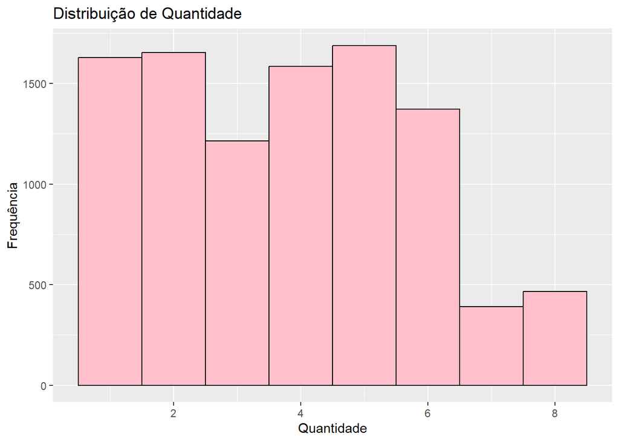

```r
ggplot(ano_2018_sample, aes(x = quantidade)) +
  geom_histogram(binwidth = 1, fill = "pink", color = "black") +
  labs(title = "Distribuição de Quantidade", x = "Quantidade", y = "Frequência")
```

##### Gráfico de densidade para a variável preço

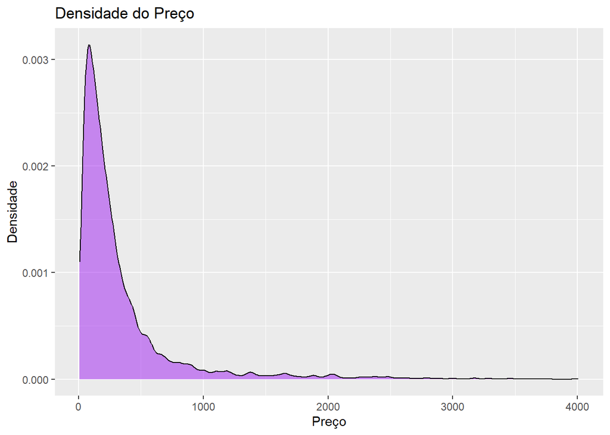

```r
ggplot(ano_2018_sample, aes(x = preco)) +
  geom_density(fill = "purple", alpha = 0.5) + labs(title = "Densidade do Preço", x = "Preço", y = "Densidade")
```

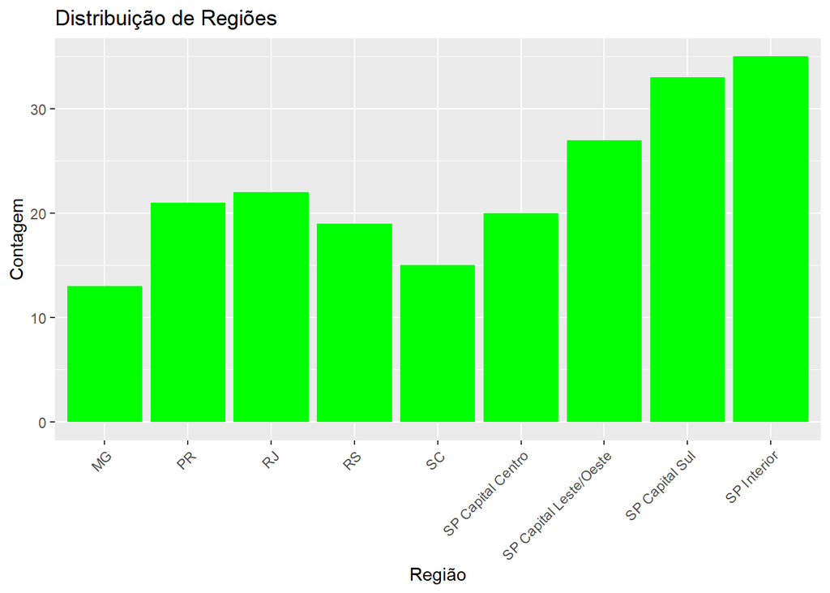

```r
ggplot(store_final, aes(x = regiao)) +
  geom_bar(fill = "green") +
  labs(title = "Distribuição de Regiões", x = "Região", y = "Contagem") +
  theme(axis.text.x = element_text(angle = 45, hjust = 1))
```

##### Histograma para a variável sales_target

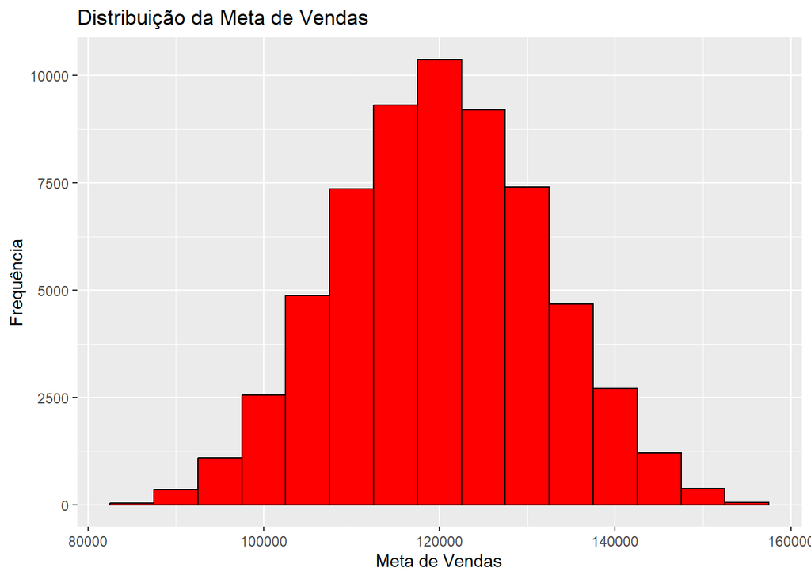

```r
ggplot(target_store_final, aes(x = sales_target)) + geom_histogram(binwidth = 5000, fill = "red", color = "black") + labs(title = "Distribuição da Meta de Vendas", x = "Meta de Vendas", y = "Frequência")
```

##### Histograma da variável preço

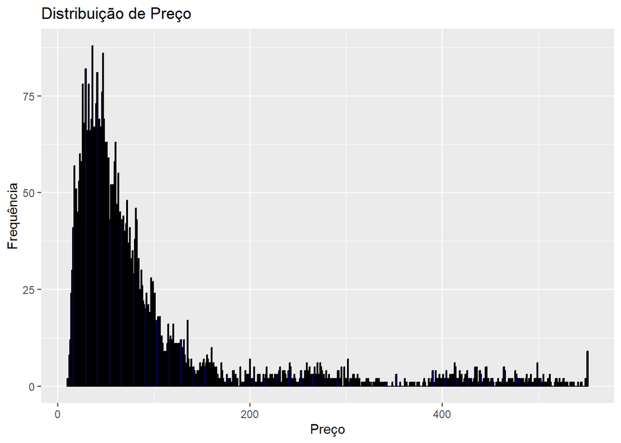

```r
ggplot(sku_price, aes(x = preco)) +
  geom_histogram(binwidth = 1, fill = "blue", color = "black") +
  labs(title = "Distribuição de Preço", x = "Preço", y = "Frequência")
```

##### Boxplot para a variável custo

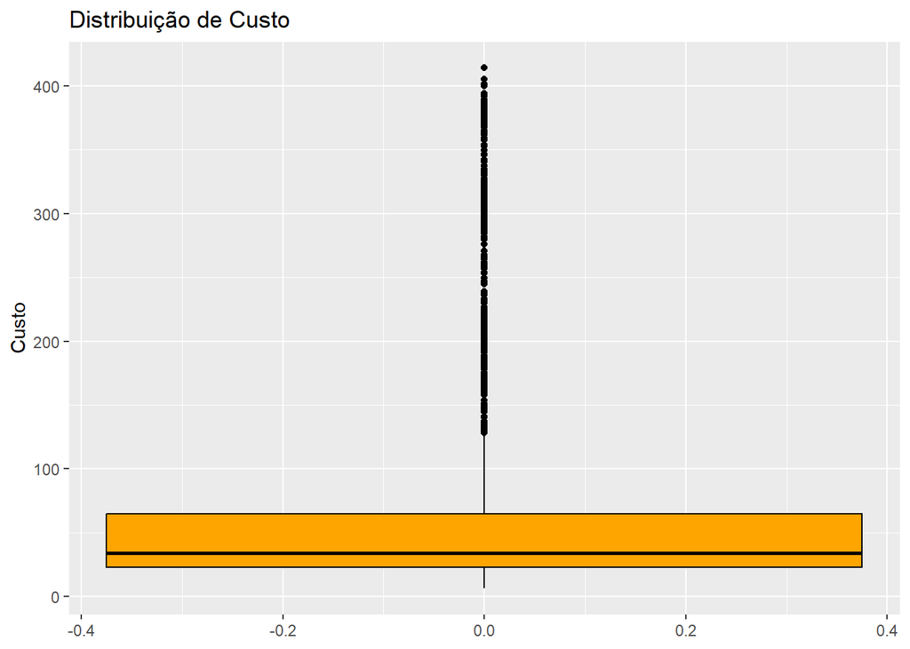

```r
ggplot(sku_cost, aes(y = custo)) +
  geom_boxplot(fill = "orange", color = "black") +
  labs(title = "Distribuição de Custo", y = "Custo")
```

##### Boxplot da variável quantidade

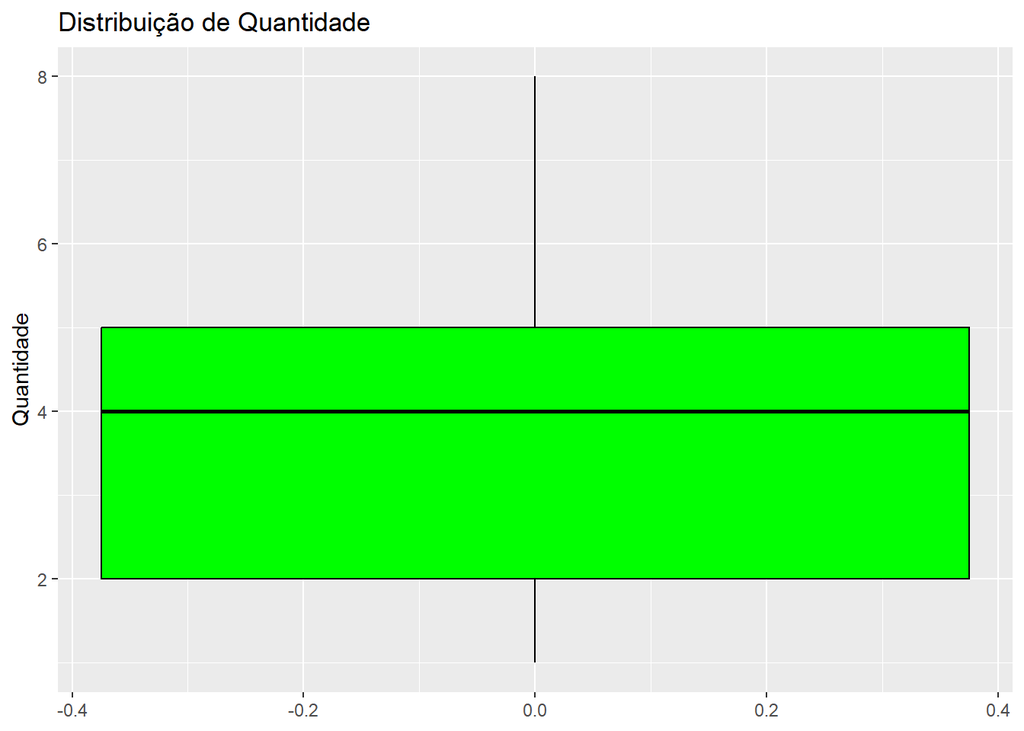

```r
ggplot(ano_2018_sample, aes(y = quantidade)) +
  geom_boxplot(fill = "green", color = "black") +
  labs(title = "Distribuição de Quantidade", y = "Quantidade")
```

### Identificação de outliers

##### Boxplot para identificar outliers na variável preço

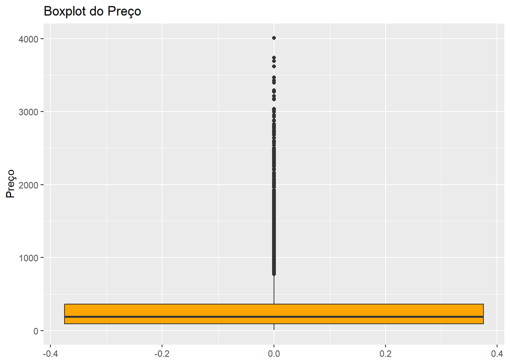

```r
ggplot(ano_2018_sample, aes(y = preco)) + geom_boxplot(fill = "orange") + labs(title = "Boxplot do Preço", y = "Preço")
```

##### Boxplot para identificar outliers na variável quantidade

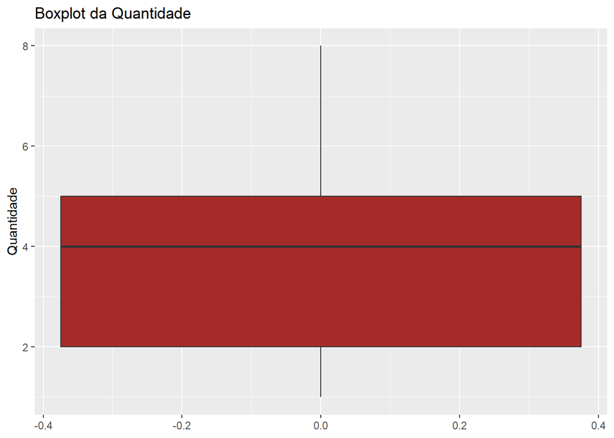

```r
ggplot(ano_2018_sample, aes(y = quantidade)) + geom_boxplot(fill = "brown") + labs(title = "Boxplot da Quantidade", y = "Quantidade")
```

##### Boxplot para identificar outliers na variável preco

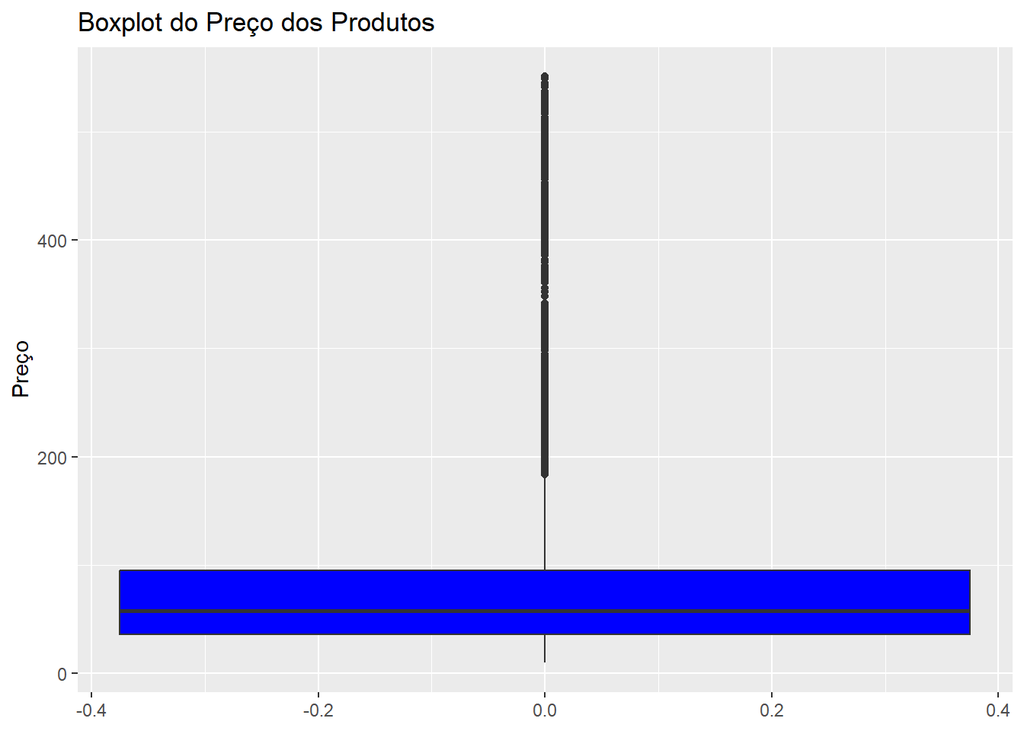

```r
ggplot(sku_price, aes(y = preco)) + geom_boxplot(fill = "blue") + labs(title = "Boxplot do Preço dos Produtos", y = "Preço")
```

##### Identificando outliers na variável “preço” do dataset ano_2018

```r
preco_outliers <- ano_2018_sample %>%
  filter(preco < quantile(preco, 0.25) - 1.5 * IQR(preco) |
         preco > quantile(preco, 0.75) + 1.5 * IQR(preco))
```

##### Identificando outliers na variável “preço” do dataset sku_price

```r
preco_outliers_sku <- sku_price %>%
  filter(preco < quantile(preco, 0.25) - 1.5 * IQR(preco) |
         preco > quantile(preco, 0.75) + 1.5 * IQR(preco))
```

##### Exibindo os dataframes com outliers

```r
preco_outliers
```

```
## # A tibble: 908 × 7
##    data       cod_vendedor cod_loja      cod_transacao quantidade cod_prod preco
##    <chr>             <int> <chr>         <chr>              <int>    <dbl> <dbl>
##  1 2018-02-20          689 RS_59         2ffb786ae1             6  6.82e11  858.
##  2 2018-02-22          344 SP Capital S… 85a0a1d587             6  8.14e11 2496.
##  3 2018-04-20          629 SP Interior_… 9a28f021f9             4  4.96e11  786.
##  4 2018-03-29          611 SP Interior_… f43ca6cd0a             7  3.02e10 1024.
##  5 2018-08-30          131 RS_17         b07018b674             5  3.04e11 1894.
##  6 2018-04-23          310 SC_39         cf9f9707c9             4  4.10e11 1729.
##  7 2018-07-30          455 SP Interior_… 45db2051dd             4  1.79e11 1105.
##  8 2018-04-24          251 SP Capital S… f6c711628d             3  2.67e11 1187.
##  9 2018-03-17          841 PR_68         ee58f8f8d4             5  8.59e11 1888.
## 10 2018-03-27          632 RS_2          767a3156d2             4  3.52e10 1646.
## # ℹ 898 more rows
```

```r
preco_outliers_sku
```

```
## # A tibble: 625 × 4
##        cod_prod data_inicio data_fim   preco
##           <dbl> <chr>       <chr>      <dbl>
##  1 185584251496 2021-04-13  2021-08-06  386.
##  2 185584251496 2021-08-07  2021-11-30  388.
##  3 185584251496 2021-12-01  2022-03-26  390.
##  4 185584251496 2022-03-27  2022-07-20  404.
##  5 185584251496 2022-07-21  2022-11-13  412.
##  6 185584251496 2022-11-14  2023-03-09  428.
##  7 185584251496 2023-03-10  2023-07-03  439.
##  8 185584251496 2023-07-04  2023-10-27  430.
##  9 185584251496 2023-10-28  2024-02-20  448.
## 10 185584251496 2024-02-21  2024-06-13  449.
## # ℹ 615 more rows
```

```r
summary(preco_outliers)
```

```
##      data            cod_vendedor     cod_loja         cod_transacao
##  Length:908         Min.   :  2.0   Length:908         Length:908
##  Class :character   1st Qu.:248.8   Class :character   Class :character
##  Mode  :character   Median :475.0   Mode  :character   Mode  :character
##                     Mean   :494.3
##                     3rd Qu.:758.5
##                     Max.   :992.0
##    quantidade       cod_prod             preco
##  Min.   :2.000   Min.   :3.018e+10   Min.   : 771.2
##  1st Qu.:4.000   1st Qu.:2.635e+11   1st Qu.: 932.3
##  Median :5.000   Median :4.686e+11   Median :1234.3
##  Mean   :5.076   Mean   :5.121e+11   Mean   :1452.9
##  3rd Qu.:6.000   3rd Qu.:8.075e+11   3rd Qu.:1810.6
##  Max.   :8.000   Max.   :9.885e+11   Max.   :4006.8
```

```r
summary(preco_outliers_sku)
```

```
##     cod_prod         data_inicio          data_fim             preco
##  Min.   :1.917e+10   Length:625         Length:625         Min.   :184
##  1st Qu.:2.542e+11   Class :character   Class :character   1st Qu.:257
##  Median :4.961e+11   Mode  :character   Mode  :character   Median :317
##  Mean   :5.195e+11                                         Mean   :346
##  3rd Qu.:7.986e+11                                         3rd Qu.:437
##  Max.   :9.885e+11                                         Max.   :551
```

## Análise Bivariada

Criando gráficos de dispersão (scatter plots) ou gráficos de barras podemos explorar as relações entre as variáveis, como `preco` vs `custo`.

##### Criando um scatter plot para visualizar a relação entre preço e custo

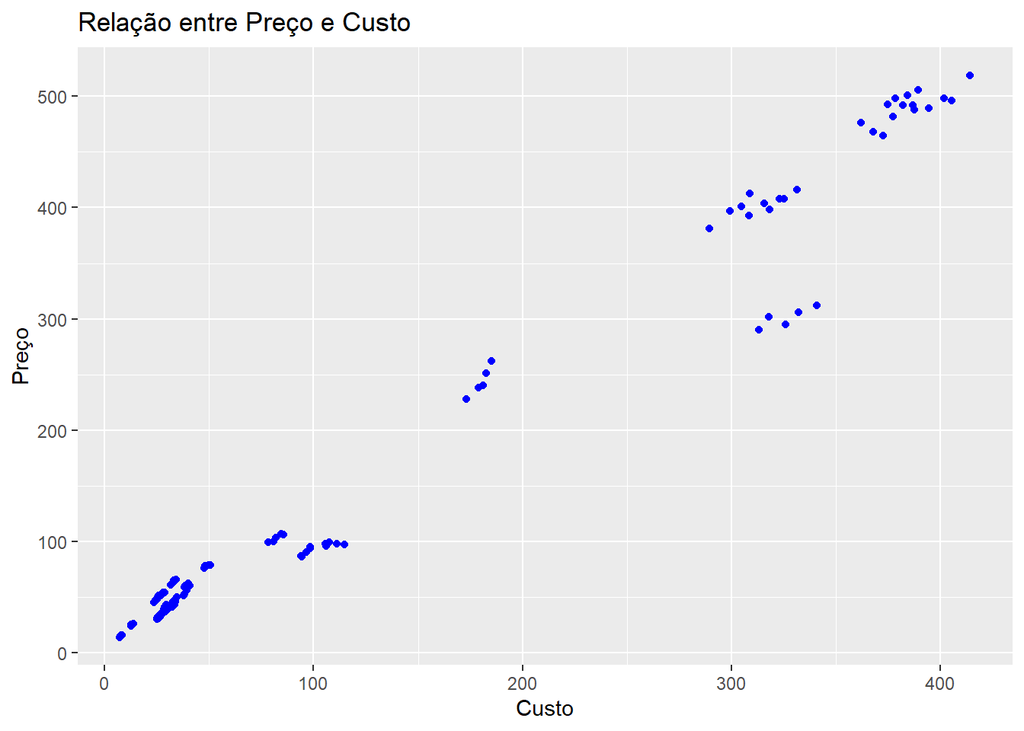

```r
ggplot(sku_data_margin_clean, aes(x = custo, y = preco)) +
  geom_point(color = "blue") +
  labs(title = "Relação entre Preço e Custo", x = "Custo", y = "Preço")
```

##### Selecionando apenas as colunas numéricas para a correlação

```r
numeric_vars <- sku_data_margin_clean %>% select(preco, custo)
numeric_vars
```

```
## # A tibble: 120 × 2
##    preco custo
##    <dbl> <dbl>
##  1  228.  173.
##  2  238.  179.
##  3  240.  181.
##  4  251.  182.
##  5  262.  185.
##  6  381.  290.
##  7  397.  299.
##  8  413.  309.
##  9  404.  316.
## 10  408.  325.
## # ℹ 110 more rows
```

##### Calculando a matriz de correlação

```r
cor_matrix <- cor(numeric_vars, use = "complete.obs")
cor_matrix
```

```
##           preco     custo
## preco 1.0000000 0.9878539
## custo 0.9878539 1.0000000
```

##### Visualizando a matriz de correlação com corrplot

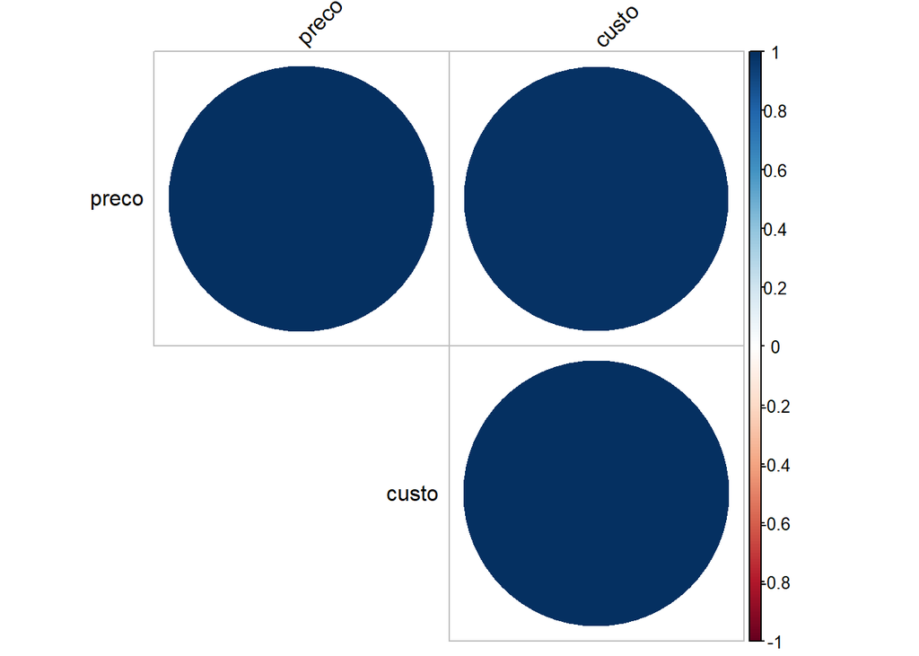

```r
corrplot(cor_matrix, method = "circle", type = "upper", tl.col = "black", tl.srt = 45)
```

Esse gráfico não gerou insights significativos. Como não encontrei uma alternativa mais adequada para utilizar essa função, optei por mantê-la conforme está.

## Análise Multivariada

#### Análise de Componentes Principais (PCA)

##### Selecionar as variáveis numéricas e remover NAs

```r
numeric_vars <- ano_2018_sample %>%
  select_if(is.numeric) %>%
  na.omit()
head(numeric_vars)
```

```
## # A tibble: 6 × 4
##   cod_vendedor quantidade     cod_prod preco
##          <int>      <int>        <dbl> <dbl>
## 1          307          6 834443993335 180.
## 2          452          4 761888570923 170.
## 3          581          4  30179342434 682.
## 4            5          5 390901022028 328.
## 5          127          1 477763275424  33.0
## 6          435          8 131551211857 693.
```

##### Verificar o número de variáveis selecionadas

```r
print(paste("Número de variáveis numéricas:", ncol(numeric_vars)))
```

```
## [1] "Número de variáveis numéricas: 4"
```

##### Executar PCA

```r
pca_result <- prcomp(numeric_vars, scale. = TRUE)
pca_result
```

```
## Standard deviations (1, .., p=4):
## [1] 1.1755284 1.0042663 0.9955494 0.7864245
##
## Rotation (n x k) = (4 x 4):
##                     PC1         PC2          PC3          PC4
## cod_vendedor 0.01778241 -0.70912330  0.704844775 -0.004666683
## quantidade   0.70670178  0.02613975  0.003788088 -0.707018355
## cod_prod     0.02483628 -0.70440760 -0.709343289 -0.005018618
## preco        0.70685185  0.01645575  0.003404612  0.707161991
```

##### Resumo do PCA

```r
summary(pca_result)
```

```
## Importance of components:
##                           PC1    PC2    PC3    PC4
## Standard deviation     1.1755 1.0043 0.9955 0.7864
## Proportion of Variance 0.3455 0.2521 0.2478 0.1546
## Cumulative Proportion  0.3455 0.5976 0.8454 1.0000
```

##### Visualizar a variância explicada pelos componentes principais

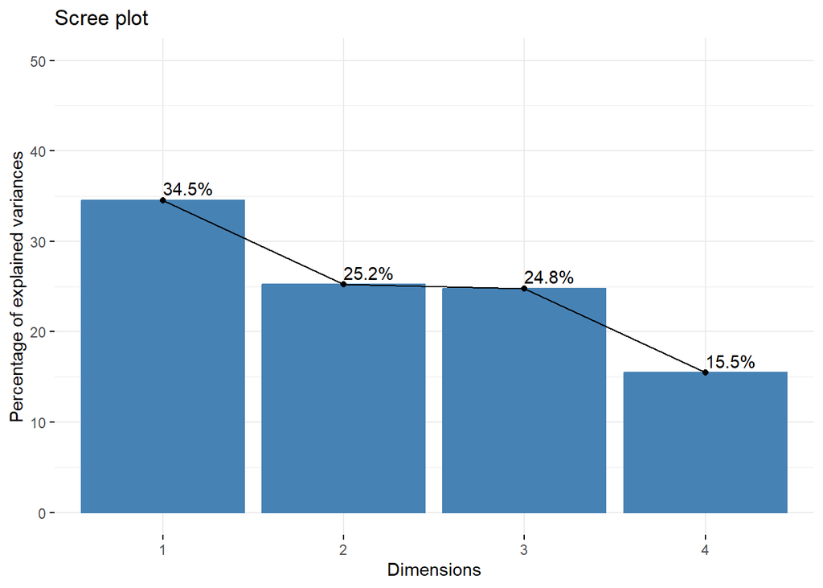

```r
fviz_eig(pca_result, addlabels = TRUE, ylim = c(0, 50))
```

## Discussão sobre Limitações e Possíveis Melhorias

**Limitações do Estudo:**

1. **Dados Ausentes:**
   - A análise encontrou valores ausentes em várias variáveis, o que pode ter influenciado os resultados da análise de correlação e PCA. Embora tenham sido removidos ou substituídos, esses valores ausentes representam uma limitação que poderia ser mitigada com um conjunto de dados mais completo.
2. **Multicolinearidade:**
   - A forte correlação entre `preco` e `custo` sugere uma possível multicolinearidade que pode distorcer modelos de regressão ou outras análises multivariadas. Isso poderia limitar a eficácia de alguns modelos preditivos se não for tratado adequadamente.
3. **Outliers:**
   - A presença de outliers pode influenciar significativamente os resultados da análise. A decisão de incluir ou excluir esses outliers pode alterar as conclusões do estudo, o que introduz uma margem de incerteza nas descobertas.
4. **Escopo da Análise:**
   - A análise focou principalmente em `preco`, `custo`, e `quantidade`. Outras variáveis, como categorias de produtos, regiões de venda, e períodos de tempo, não foram exploradas nesse momento, mas relacioná-las poderia nos fornecer insights adicionais.

**Possíveis Melhorias e Sugestões para Análises Futuras:**

1. **Coleta e Integração de Dados Mais Abrangente:**
   - Melhorar a coleta de dados para reduzir a quantidade de valores ausentes e garantir que todos os aspectos relevantes dos produtos e vendas sejam capturados pode aumentar a precisão das análises futuras.
2. **Análise de Séries Temporais:**
   - Realizar essa análise com as séries temporais pode nos fornecer insights sobre as tendências e sazonalidades que não foram capturados na análise atual.
3. **Exploração de Outliers:**
   - Realizar uma análise mais detalhada dos outliers identificados para entender melhor se eles representam erros de dados ou casos excepcionais que devem ser mantidos no modelo.
4. **Análise de Sensibilidade:**
   - Conduzir uma análise de sensibilidade para entender como as alterações nos dados (como a remoção de outliers ou preenchimento de valores ausentes) afetam os resultados poderia fortalecer as conclusões.

Com essas melhorias e considerações, nossas análises futuras poderão ser mais robustas, oferecendo uma compreensão mais completa dos dados e suas implicações para a tomada de decisões.